# Your Digest for Saturday, Oct 07, 2023 11:59 PM

# Benign essential tremor

#2020GM-NOV/Q35

- Everyone has a physiological tremor of 8-12 Hz which is enhanced by anxiety, caffeine, hyperthyroidism and drugs.
- The amplitude of this is increased in **Benign essential tremor.*
- Features of essential tremor
  - Starts **early in life**.
  - Bilateral, *fast*, *low amplitude* tremors.
  - Presents with bilateral tremmor. *Parkinsonian tremmor is usually unilateral at first.*
  - The tremor is postural : like when holding a glass.
  - Titubation - thrymic up and down or side to side head movements.
  - Severe impairment of function is rare.
  - There may be a component of intention tremor.
- It is Familial - #autosomalDominant inheritance
- Treatment: no effective treatment; alcohol, beta blockers, primidone, or gabapentin may help.
- Stereotactic thalamotomy and thalamic DBS can be used in severe cases.

[figure not shown]

Neuro - Sensory and motor neuropathy

#### Clinical features of hypoparathyroidism *Hypocalcemia*

##### Acute hypocalcemia

- Signs are carpopedtal spasm and tetany.
- Perioral numbness, paraesthesia of hands and feet
- Prolonged QT interval.
- Seizures

##### Chronic hypocalcemia

- In hypoparathyroidism, there is **increased** bone mineral density (due to **decreased** turnover) but the bone is not properly formed.
  - So there are **increased fractures**
- Features unique to hypocalcemia which occurs *due to **hypoparathyroidism***
  - Extrapyramidal symptoms due to **basal ganglia calcification**
  - Cataracts
  - Reduced bone turnover
  - Dental abnormalities

#### laboratory features of hypoparathyroidism

- Hypocalcemia with low or inapproprirately normal PTH level
- **hyperphosphatemia**
- Normal or low serum 25-hydroxyvitamin D (25[OH]D)
- Normal or low 1,25-dihydroxyvitamin D - decreased renal activation in the absense of PTH
- **Elevated fractional urinary excretion of Calcium.**

#### Idiopathic primary hyperparathyroidism

- **rare**
- Commonest cause is post surgical. (roughtly 80%)
- If not that, it is autoimmune. (roughly 20%)
  - Associated with vitiligo, other autoimmune diseases and cutaneous candiasis
- Caused by a **defect in PTH receptor** -> mutation in the GNAS-1 protein which is coupled to the PTH recepors. So there is *end organ resistance to PTH*.
- Biochemical manifestations are just like hypoparathyroidism (Low Ca2+ and high Phosphate)
- **BUT** having **HIGH PTH level**
- Patients have **albright phenotype**

> Albright's hereditary osteodystrophy (AHO) is a characteristic skeletal phenotype, including short stature, obesity, round face, and brachydactyly. AHO appears in patients with *pseudohypoparathyroidism* (PHP) who have resistance to PTH and in their eumetabolic family members who have *pseudopseudohypoparathyroidism* (PPHP).  
> [Source](https://pubmed.ncbi.nlm.nih.gov/8636385/)

[figure not shown]

[output not shown]

Transferrin saturation corresponds to body iron status.  
#2020SBR-NOV/Q7  
Normal transferrin saturation is 20 - 50%.[Source](https://emedicine.medscape.com/article/2087960-overview)  
Note that transferrin saturation **increaes** with aplastic anaemia and sideroblastic anaemia. (probably because the bone marrow isn't using up the liberated iron to to make new cells)

# Sideroblastic anaemia

A form of anaemia where the defect lies in iron incorporation into haemoglobing. The iron accumulates in mitochondria of erythrocyte precursors which arange around the nucleus. The characteristic histological appearance is of a **ring sideroblast**. The disease is a laboratory diagnosis.

## Antiphospholipid syndrome - APLS / APS

**Lupus anticoagulants**: "Lupus anticoagulants" actually refers to an **anticoagulant effect** of several types of **antibodies**.  
However, they actually predispose to *THROMBOSIS* in vivo.

- Acquired factor deficiency -> usually due to acquired factor **inhibition**.
- Commonest such disease is Acquired factor eight (VIII) deficiency -> "**acquired haemophilia A**".
- Predisposing factors : *cancer*, *autoimmune syndrome* or *postpartum*.
- Presentation: haemarthrosis is *rare*. Patients will come with **subcutaneous, retroperitoneal or intramuscular bleeding** and **prolonged APPT**.  
  Recombinant factor VIII Or "bypassing product".

> [!INFO] Bypassing agents:  
> **FEIBA (factor VIII inhibitor bypassing activity)** – This is a PCC from plasma that contains factor VIIa along with factors II, IX, and X ([table 3](https://www.uptodate.com/contents/image?imageKey=HEME%2F94210&topicKey=HEME%2F1305&search=acquired%20haemophilia&rank=1%7E52&source=see_link)). (See "Treatment of bleeding and perioperative management in hemophilia A and B", section on 'Bypassing products (rFVIIa products or FEIBA)'.)  
> -**Recombinant activated factor VII (rFVIIa)** – There are two brands with different dosing and indications. (See "Recombinant factor VIIa: Administration and adverse effects", section on 'Available products and their properties'.)

### Prophylaxis against malaria infection

#2020GM-NOV/Q43

- Mainly important in travellers.
- For **falciparum** (which is chloroquine resistant in most regions) endemic regions:
  - Atovaquone-proguanil - most expensive one but has less side effects.
  - mefloquine - taken weakly; more convenient for long term travellers.
  - Doxycyline - effective against falciparum and other types of malaria. Taken daily and can cause *sun sensitization*.
  - tafenoquine
  - All high highly effective at preventing malaria.
- Chloroquine can technically be used if the destination has chloroquine senstive falciparum but this is **very rare**.
- For **vivax** endemic areas, *chloroquine and tafenoquine* can be given provided the traveller does not have G6PD deficiency.

> For substances like inulin: $$
> \large GFR= \frac{Urine\space Concentration \times Urine\space flow}{Plasma\space Concentration}
> $$

### MCD (minimal change disease)

**MCD** in adults:  
Causes of MCD:

- Majority are idiopathic.
- Drugs:
  - NSAID induced
  - Ampicillin
  - Lithium, (mercury - it's also a cause for membranous nephropathy)
  - D-penicillamine
  - Malignancies, particulartly haematologic ones: **Hodgkin lymphoma** and non hodgkin lymphoma (paraneoplastic)
- Infections like syphilis, TB, mycoplasma.
- The subepithelial deposits *cause the basement membrane to thicken with visible '**spike**' formation.* Spikes eventually encase the deposited immune complexes.
- Most often idiopathic.
  - Need to exclude **hepatitis B**, **SLE**, **thyroiditis**, some drugs (*penicillamine*, gold / *mercury*, **captopril**)
  - > [!INFO] Mnemonic: hepatitis B - mem**B**ranous

### Minimal change Vs. FSGS

> MCD and FSGS are like cousins; FSGS is the evil cousin.  
> 📑Haematuria is commoner in FSGS than in MCD.  
> 📑MCD shows *selective protein loss* -> i.e mainly albumin and not higher molecular weight proteins like immunoglobulins. FSGS shows *non-selective proteinuria*.  
> 📑FSGS shows poor response to corticosteroids.  
> FSGS : FSGS changes are visible on light microscopy. MCD: few changes visible on light microscopy.

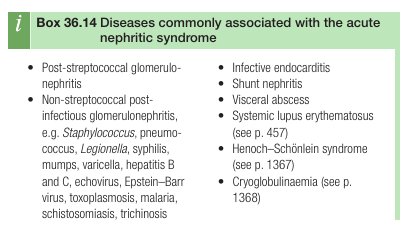

> Note visceral abscess, cryoglobulinaemia, and *non-streptococcal post infectious glomerulonephritis*.  
> #2020GM-NOV/Q36
1. The **commonest glomerular disease found on biopsy!** -> replaced PSGN as the commonest glomerulonephritis world wide.
2. 📑IgA📑It causes **recurring episodes** of microscopic or gross haematuria lasting a few days. Usually reccurs every few months after the onset.
3. Begins with *haematuria* 1-2 days after non specific *upper respiratory tract infection.*
   1. Suspect patient has "episodes of gross haematuria following URTI".
4. Pathogenesis may be due to *dysregulated mucosal type IgA reponsones* (see K and C page 1362)
5. May be related to *Henoch Schonlein purpura* which has mesangial IgA deposition as well as systemic involvement.
   1. > [!INFO] A for alternate
6. Progression to CKD is slow (if at all - *occurs in about 40 of cases*)
   1. If CKD occurs, the treatment is kidney transplant, BUT *recurrent IgA deposition in the allograft is common.*

#### Management of IgA nephropathy

#2020SBR-NOV/Q6

- Mainstay is optimized *supportive care* with
  - Blood pressure control
  - RAAS inhibitors for control of proteinuria;
  - Immunosuppessive therapy is a last resort because iffective immunosuppressive therapy, while effective has significant side effects.
- **All patients *with or without hypertension*** should receive **either** **ACEi or ARB** to reduce proteinuria and preserve renal function. If persistently proteinuric on ACEi or ARB, change to the other drug or add SGLT-2 inhibitor.
  - If proteinuria > 1g / day persists persists for 3 months with supportive measures above, **add a steroid.** (as these patients have a higher risk of progressing to ESKD).
- Tonsillectomy can reduce proteinuria and haematuria in patients with recurrent tonsilitis.

### 📑Post streptococcal glomerulonephritis PSGN

#2020GM-NOV/Q36  
Autoimmune response to *nephritogenic* GABHS (Group A beta haemolytic streptococci) (strep. pyogenes) -> Immune *complexes* (IgG and complement) are formed and deposited in glomeruli -> activation of📑 **alternate** complement pathway (hypocomplimentaemia occurs) -> recruitment of *inflammatory cells* -> glomerular injury.  
+ >[!TIP] mnemonic: streptococci on a petri dish will look like stars in the sky.

## Causes of mixed pixture

It is uncommon.  
?commonly presents as nephrotic syndrome <- confirm.  
C3 COMPLEMENT LEVELS ARE LOW.

- Type 1: subendothelial immune complex deposition -> splitting of capillary basement membrane -> *tramline appearance*.
  - Persistently low C3 and normal C4 but activation of the *classical!?* complement pathway - Kumar and Clarke
- Type 2: AKA **C3 nephropathy**
  - linear intramembranous-membranous deposits
  - C3 is and activation is via the **alternativeb** complement pathway.
- Type 3:
  - Mixture of Type 1 and Type 2.  
    These classifications have been found to be somewhat outdated. See UpToDate.

**Symptoms** Usually **more prominent on one side**.  
*Parkinsonian tremmor is usually unilateral at first.*

[output not shown]

## Immediate management

> [!INFO] Give *Aspirin* 300 (**three hundred**)mg as soon as a clinical diagnosis of ischemic stroke is made. [Source](https://shri.lk/wp-content/uploads/2015/07/Management-of-Stroke.pdf)  
> and continue *indefinitely* thereafter.

> Antiplatelets or antithrombotics **should not be started for 24 hours** after fibrinolytic therapy.

#2020GM-NOV/Q38

> [!TIP] Exclusion criteria you wouldn't think of
> - GI malignancy
> - PLT < 100,000
> - Currently on anticoagulats (warfarin or DOACs) with elevated coagulation studies

> **Durations**
> - Ischemic stroke, severe head trauma, or intra cranial or intraspinal surgery within *3 months.*
> - GI bleed within *3 weeks*

## Local inclusion and exclusion criteria (from 2015)

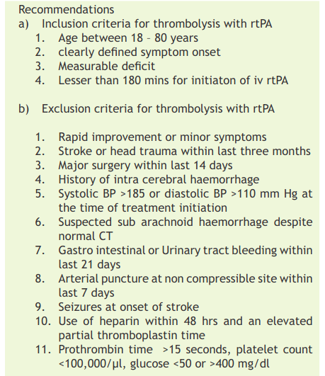

> **tenecteplase**, given in a single bolus at 0.25 mg/kg (maximum 25 mg), *has similar efficacy and safety outcomes* compared with **alteplase**

### Side effects of tPA

- ICH
> - Intravenous thrombolysis with tissue plasminogen activator (tPA) improves outcome in a selected group of patients with acute ischemic stroke but is **associated with a 10-fold increased risk of symptomatic intracerebral hemorrhage (SICH)** [Source](https://jamanetwork.com/journals/jamaneurology/fullarticle/795564)
- Angiooedema
  - **Orolingual angioedema occurs in 1 to 8 percent** of patients treated with alteplase or tenecteplase for ischemic stroke and it is typically mild, transient, and *contralateral to the ischemic hemisphere*

# Hereditary Haemochromatosis (HH)

> [!INFO] Classic triad of features: Liver, pancreas and skin.  
> Ferritin levels > 300 in males or 200 in females suggest iron overload and ferritin > 1000 strongly suggests the need for phlebotomy.
- People with organ injury from iron overload : Phlebotomy
- People with isolated elevations in ferritin or transferrin saturation :
  - Ferritin can be elevated due to alcoholic liver disease itself. Cessation of alcohol - and treating other causes of liver dysfunction - is very important in management.
  - Phlebotomy and expectant management are both options for people with isolated elevation of ferritin or TSAT.
- Heterozygous individuals
  - Iron overload is very rare in them.

### Extraintestinal manifestations of Crohn's disease IBD

#2021SBR-NOV/Q08  
Extraintestinal manifestations are common to both diseases.  
**Joint complications are the most common**:

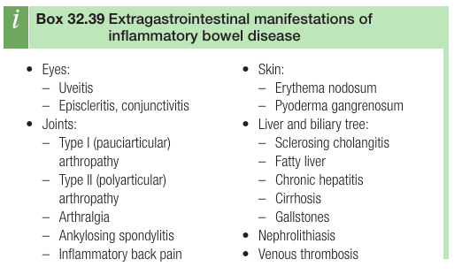

1. Migratory arthitis - appendicular skeleton. *Parallels intestinal disease*. Treatment of intestinal disease resolves arthritis.

> PAN **does not involve veins!** (i.e arteritis: not vasculitis)  
> 1. Renal involvement is due to luminal narrowing and ischemia of renal arterioles but not due to glomerular inflammation or necrosis.  
> 2. Renal arterial aneurysms and renal infarctions
8. Mononeuritis mulitiplex - vaso vasorum infarctions
9. Skin - subcutaneous haemorrhage and gangrene
10. **Somehow, lungs aren't involved**.